[figure not shown]

# Objective

- How to create a dataset object.

# Data Preparation with PyTorch

Crack detection has vital importance for structural health monitoring and inspection. We would like to train a network to detect Cracks, we will denote the images that contain cracks as positive and images with no cracks as negative. In this lab you are going to have to build a dataset object. There are five questions in this lab, Including some questions that are intermediate steps to help you build the dataset object. You are going to have to remember the output for some of the questions.

## Table of Contents

- Download data
- Imports and Auxiliary Functions
- Examine Files
- **Question 1:find number of files**
- Assign Labels to Images
- **Question 2 : Assign labels to image**
- Training and Validation Split
- **Question 3: Training and Validation Split**
- Create a Dataset Class
- **Question 4:Display training dataset object**
- **Question 5:Display validation dataset object**

Estimated Time Needed: **25 min**

## Download Data

In this section, you are going to download the data from IBM object storage using **wget**, then unzip them. **wget** is a command the retrieves content from web servers, in this case its a zip file. Locally we store the data in the directory **/resources/data** . The **-p** creates the entire directory tree up to the given directory.

First, we download the file that contains the images, if you dint do this in your first lab uncomment:

```python
!wget https://s3-api.us-geo.objectstorage.softlayer.net/cf-courses-data/CognitiveClass/DL0321EN/data/images/concrete_crack_images_for_classification.zip -P /resources/data
```

```
--2020-10-21 11:34:52--  https://s3-api.us-geo.objectstorage.softlayer.net/cf-courses-data/CognitiveClass/DL0321EN/data/images/concrete_crack_images_for_classification.zip
Resolving s3-api.us-geo.objectstorage.softlayer.net (s3-api.us-geo.objectstorage.softlayer.net)... 67.228.254.196
Connecting to s3-api.us-geo.objectstorage.softlayer.net (s3-api.us-geo.objectstorage.softlayer.net)|67.228.254.196|:443... connected.
HTTP request sent, awaiting response... 200 OK
Length: 245259777 (234M) [application/zip]
Saving to: ‘/resources/data/concrete_crack_images_for_classification.zip’

concrete_crack_imag 100%[===================>] 233.90M  25.1MB/s    in 9.2s

2020-10-21 11:35:01 (25.5 MB/s) - ‘/resources/data/concrete_crack_images_for_classification.zip’ saved [245259777/245259777]
```

We then unzip the file, this ma take a while:

```python
!unzip -q  /resources/data/concrete_crack_images_for_classification.zip -d  /resources/data
```

```
replace /resources/data/Negative/18476.jpg? [y]es, [n]o, [A]ll, [N]one, [r]ename: ^C
```

## Imports and Auxiliary Functions

The following are the libraries we are going to use for this lab:

```python
from PIL import Image
import matplotlib.pyplot as plt
import os
import glob
import torch
from torch.utils.data import Dataset
```

We will use this function in the lab to plot:

```python
def show_data(data_sample, shape = (28, 28)):
    plt.imshow(data_sample[0].numpy().reshape(shape), cmap='gray')
    plt.title('y = ' + data_sample[1])
```

## Examine Files

In the previous lab, we create two lists; one to hold the path to the Negative files and one to hold the path to the Positive files. This process is shown in the following few lines of code.

We can obtain the list that contains the path to the **negative files** as follows:

```python
directory="data"
negative='Negative'
negative_file_path=os.path.join(directory,negative)
negative_files=[os.path.join(negative_file_path,file) for file in  os.listdir(negative_file_path) if file.endswith(".jpg")]
negative_files.sort()
negative_files[0:3]
```

```
['data/Negative/00001.jpg',
 'data/Negative/00002.jpg',
 'data/Negative/00003.jpg']
```

We can obtain the list that contains the path to the **positive files** files as follows:

```python
positive="Positive"
positive_file_path=os.path.join(directory,positive)
positive_files=[os.path.join(positive_file_path,file) for file in  os.listdir(positive_file_path) if file.endswith(".jpg")]
positive_files.sort()
positive_files[0:3]
```

```
['data/Positive/00001.jpg',
 'data/Positive/00002.jpg',
 'data/Positive/00003.jpg']
```

## Question 1

**Find the **combined** length of the list `positive_files` and `negative_files` using the function `len` . Then assign it to the variable `number_of_samples`</b>**

```python
number_of_samples=len(negative_files)+len(positive_files)
number_of_samples
```

```
40000
```

## Assign Labels to Images

In this section we will assign a label to each image in this case we can assign the positive images, i.e images with a crack to a value one and the negative images i.e images with out a crack to a value of zero **Y**. First we create a tensor or vector of zeros, each element corresponds to a new sample. The length of the tensor is equal to the number of samples.

```python
Y=torch.zeros([number_of_samples])
```

As we are using the tensor **Y** for classification we cast it to a `LongTensor`.

```python
Y=Y.type(torch.LongTensor)
Y.type()
```

```
'torch.LongTensor'
```

With respect to each element we will set the even elements to class one and the odd elements to class zero.

```python
Y[::2]=1
Y[1::2]=0
```

[output not shown]

## Question 2

**Create a list all_files such that the even indexes contain the path to images with positive or cracked samples and the odd element contain the negative images or images with out cracks. Then use the following code to print out the first four samples.**

```python
all_files[::2]=positive_files
all_files[1::2]=negative_files
all_files
```

```
['data/Positive/00001.jpg',
 'data/Negative/00001.jpg',
 'data/Positive/00002.jpg',
 'data/Negative/00002.jpg',
 'data/Positive/00003.jpg',
 'data/Negative/00003.jpg',
 'data/Positive/00004.jpg',
 'data/Negative/00004.jpg',
 'data/Positive/00005.jpg',
 'data/Negative/00005.jpg',
 'data/Positive/00006.jpg',
 'data/Negative/00006.jpg',
 'data/Positive/00007.jpg',
 'data/Negative/00007.jpg',
 'data/Positive/00008.jpg',
 'data/Negative/00008.jpg',
 'data/Positive/00009.jpg',
 'data/Negative/00009.jpg',
 'data/Positive/00010.jpg',
 'data/Negative/00010.jpg',
 'data/Positive/00011.jpg',
 'data/Negative/00011.jpg',
 'data/Positive/00012.jpg',
 'data/Negative/00012.jpg',
 'data/Positive/00013.jpg',
 'data/Negative/00013.jpg',
 'data/Positive/00014.jpg',
 'data/Negative/00014.jpg',
 'data/Positive/00015.jpg',
 'data/Negative/00015.jpg',
 'data/Positive/00016.jpg',
 'data/Negative/00016.jpg',
 'data/Positive/00017.jpg',
 'data/Negative/00017.jpg',
 'data/Positive/00018.jpg',
 'data/Negative/00018.jpg',
 'data/Positive/00019.jpg',
 'data/Negative/00019.jpg',
 'data/Positive/00020.jpg',
 'data/Negative/00020.jpg',
```

[output cut: 946 more lines]

```
 'data/Positive/00494.jpg',
 'data/Negative/00494.jpg',
 'data/Positive/00495.jpg',
 'data/Negative/00495.jpg',
 'data/Positive/00496.jpg',
 'data/Negative/00496.jpg',
 'data/Positive/00497.jpg',
 'data/Negative/00497.jpg',
 'data/Positive/00498.jpg',
 'data/Negative/00498.jpg',
 'data/Positive/00499.jpg',
 'data/Negative/00499.jpg',
 'data/Positive/00500.jpg',
 'data/Negative/00500.jpg',
 ...]
```

code used to print samples:

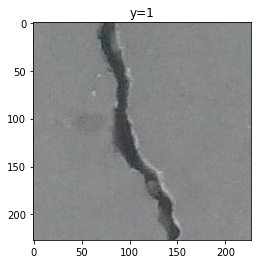

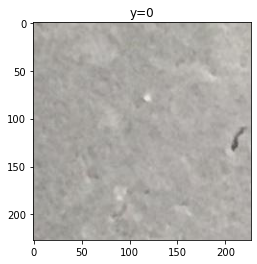

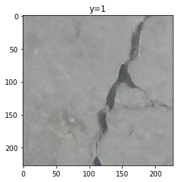

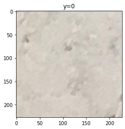

```python
for y,file in zip(Y, all_files[0:4]):
    plt.imshow(Image.open(file))
    plt.title("y="+str(y.item()))
    plt.show()
```

## Training and Validation Split

When training the model we split up our data into training and validation data. It If the variable train is set to `True` the following lines of code will segment the tensor **Y** such at the first 30000 samples are used for training. If the variable train is set to `False` the remainder of the samples will be used for validation data.

```python
train=False

if train:
    all_files=all_files[0:30000]
    Y=Y[0:30000]

else:
    all_files=all_files[30000:]
    Y=Y[30000:]
```

## Question 3

```python
train=True

if train:
    all_files=all_files[0:30000]
    Y=Y[0:30000]

else:
    all_files=all_files[30000:]
    Y=Y[30000:]
```

Just a note the images printed out in question two are the first four training samples.

## Create a Dataset Class

In this section, we will use the previous code to build a dataset class.

Complete the code to build a Dataset class `dataset`. As before, make sure the even samples are positive, and the odd samples are negative. If the parameter `train` is set to `True`, use the first 30 000 samples as training data; otherwise, the remaining samples will be used as validation data.

```python
class Dataset(Dataset):

    # Constructor
    def __init__(self,transform=None,train=True):
        directory="data"
        positive="Positive"
        negative="Negative"

        positive_file_path=os.path.join(directory,positive)
        negative_file_path=os.path.join(directory,negative)
        positive_files=[os.path.join(positive_file_path,file) for file in  os.listdir(positive_file_path) if file.endswith(".jpg")]
        positive_files.sort()
        negative_files=[os.path.join(negative_file_path,file) for file in  os.listdir(negative_file_path) if file.endswith(".jpg")]
        negative_files.sort()

        self.all_files=[None]*number_of_samples
        self.all_files[::2]=positive_files
        self.all_files[1::2]=negative_files
        # The transform is goint to be used on image
        self.transform = transform
        #torch.LongTensor
        self.Y=torch.zeros([number_of_samples]).type(torch.LongTensor)
        self.Y[::2]=1
        self.Y[1::2]=0

        if train:

            self.Y=self.Y[0:30000]
            self.len=len(self.all_files)
        else:

            self.Y=self.Y[30000:]
            self.len=len(self.all_files)





    # Get the length
    def __len__(self):
        return self.len

    # Getter
    def __getitem__(self, idx):


        image=Image.open(self.all_files[idx])
        y=self.Y[idx]


        # If there is any transform method, apply it onto the image
        if self.transform:
            image = self.transform(image)

        return image, y
```

## Question 4

```python
dataset = Dataset()
samples = [dataset.Y [index] for index in Y]
for sample in samples:
    plt.imshow(dataset[sample][9])
    plt.xlabel("y="+str(dataset[sample][1].item()))
    plt.title("training data, sample {}".format(int(sample)))
    plt.show()
```

[output not shown]

## Question 5

```python
for sample  in samples:
    plt.imshow(dataset[sample][0])
    plt.xlabel("y="+str(dataset[sample][1].item()))
    plt.title("validation data, sample {}".format(int(sample)))
    plt.show()
```

## About the Authors:

<a href=\"https://www.linkedin.com/in/joseph-s-50398b136/\">Joseph Santarcangelo</a> has a PhD in Electrical Engineering, his research focused on using machine learning, signal processing, and computer vision to determine how videos impact human cognition. Joseph has been working for IBM since he completed his PhD.

## Change Log

| Date (YYYY-MM-DD) | Version | Changed By | Change Description |
| --- | --- | --- | --- |
| 2020-09-18 | 2.0 | Shubham | Migrated Lab to Markdown and added to course repo in GitLab |

Copyright © 2018 cognitiveclass.ai. This notebook and its source code are released under the terms of the <a href=\"https://bigdatauniversity.com/mit-license/\\">MIT License</a>